# Lab 6: Inference for numerical data

**Not for submission:** Note that in order to ease the burden during midterm week, this Lab will not be submitted and all answers will be shown in the document below. We will discuss the results in Lab and you may use this Lab as a reference for how to perform inference on and plot numerical data.

## North Carolina births

In 2004, the state of North Carolina released a large data set containing information on births recorded in this state. This data set is useful to researchers studying the relation between habits and practices of expectant mothers and the birth of their children. We will work with a random sample of observations from this data set.

## R Packages

We will be using the `statsr` package that we used in Lab 5. We’ll also be using the `tidyverse` library (which includes `ggplot2` for visualization and `dplyr` for data manipulation).

```r
library(statsr)
library(tidyverse)
```

Remember, loading a package is something you need to do each time you launch a new R session and in each of your R Markdown files that have code that relies on this package.

## Exploratory analysis

Load the `nc` data set into our workspace.

```r
load(url("https://www.openintro.org/data/rda/ncbirths.rda"))
```

We have observations on 13 different variables, some categorical and some numerical. The meaning of each variable is as follows.

| variable | description |
| --- | --- |
| `fage` | father’s age in years. |
| `mage` | mother’s age in years. |
| `mature` | maturity status of mother. |
| `weeks` | length of pregnancy in weeks. |
| `premie` | whether the birth was classified as premature (premie) or full-term. |
| `visits` | number of hospital visits during pregnancy. |
| `marital` | whether mother is `married` or `not married` at birth. |
| `gained` | weight gained by mother during pregnancy in pounds. |
| `weight` | weight of the baby at birth in pounds. |
| `lowbirthweight` | whether baby was classified as low birthweight (`low`) or not (`not low`). |
| `gender` | gender of the baby, `female` or `male`. |
| `habit` | status of the mother as a `nonsmoker` or a `smoker`. |
| `whitemom` | whether mom is `white` or `not white`. |

1. What are the cases in this data set? How many cases are there in our sample?

Remember that you can answer this question by viewing the data in the data viewer or by using the following command:

```r
str(nc)
```

```
## tibble [1,000 × 13] (S3: tbl_df/tbl/data.frame)
##  $ fage          : int [1:1000] NA NA 19 21 NA NA 18 17 NA 20 ...
##  $ mage          : int [1:1000] 13 14 15 15 15 15 15 15 16 16 ...
##  $ mature        : Factor w/ 2 levels "mature mom","younger mom": 2 2 2 2 2 2 2 2 2 2 ...
##  $ weeks         : int [1:1000] 39 42 37 41 39 38 37 35 38 37 ...
##  $ premie        : Factor w/ 2 levels "full term","premie": 1 1 1 1 1 1 1 2 1 1 ...
##  $ visits        : int [1:1000] 10 15 11 6 9 19 12 5 9 13 ...
##  $ marital       : Factor w/ 2 levels "married","not married": 1 1 1 1 1 1 1 1 1 1 ...
##  $ gained        : int [1:1000] 38 20 38 34 27 22 76 15 NA 52 ...
##  $ weight        : num [1:1000] 7.63 7.88 6.63 8 6.38 5.38 8.44 4.69 8.81 6.94 ...
##  $ lowbirthweight: Factor w/ 2 levels "low","not low": 2 2 2 2 2 1 2 1 2 2 ...
##  $ gender        : Factor w/ 2 levels "female","male": 2 2 1 2 1 2 2 2 2 1 ...
##  $ habit         : Factor w/ 2 levels "nonsmoker","smoker": 1 1 1 1 1 1 1 1 1 1 ...
##  $ whitemom      : Factor w/ 2 levels "not white","white": 1 1 2 2 1 1 1 1 2 2 ...
```

Here each case (i.e. row in the data frame) is a birth, and there are 1000 cases in this sample (i.e. rows in the data frame).

As you review the variable summaries, consider which variables are categorical and which are numerical. For numerical variables, are there outliers? If you aren’t sure or want to take a closer look at the data, make a graph.

Consider the possible relationship between a mother’s smoking habit and the weight of her baby. Plotting the data is a useful first step because it helps us quickly visualize trends, identify strong associations, and develop research questions.

2. Make a side-by-side boxplot of `habit` and `weight`. What does the plot highlight about the relationship between these two variables?

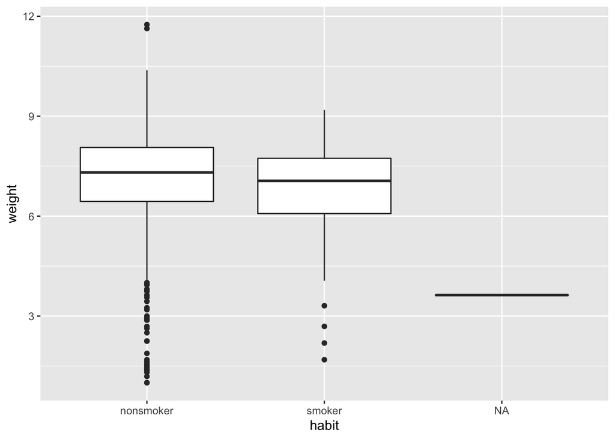

```r
ggplot(nc, aes(x=habit, y=weight)) +
  geom_boxplot()
```

We see the median weight for babies born to non-smoking parents is higher than the median for smoking parents. The max, 1st, and 3rd quantiles are also higher, but the minimum is lower. The IQR seems to be very close between the two groups. Both distributions are roughly symmetric, but non-smokers tend to have more values considered as outliers by the default settings. This could imply that the size of that group may be much larger than the smoking group.

The box plots show how the medians of the two distributions compare, but we can also compare the means of the distributions using the following to first group the data by the `habit` variable, and then calculate the mean `weight` in these groups using the `mean` function.

```r
nc %>%
  group_by(habit) %>%
  summarise(mean_weight = mean(weight))
```

```
## # A tibble: 3 x 2
##   habit     mean_weight
##   <fct>           <dbl>
## 1 nonsmoker        7.14
## 2 smoker           6.83
## 3 <NA>             3.63
```

There is an observed difference, but is this difference statistically significant? In order to answer this question we will conduct a hypothesis test.

## Inference

3. Are all conditions necessary for inference satisfied? Comment on each. You can compute the group sizes using the same `group_by` command above but replacing `mean(weight)` with `n()`, as shown below.

```r
nc %>%
  group_by(habit) %>%
  summarise(sample_size = n())
```

```
## # A tibble: 3 x 2
##   habit     sample_size
##   <fct>           <int>
## 1 nonsmoker         873
## 2 smoker            126
## 3 <NA>                1
```

From information given, we assume that cases are independent (both within smoking habit group and between smoking habit groups). Each sample size is larger than 30. And the boxplots did not reveal strong skew.

Let $\mu_{non-smoker}$ denote the average weights of babies born to non-smoking mothers and $\mu_{smoker}$ denote the average weights of babies born to smoking mothers. The hypotheses for testing if the average weights of babies born to smoking and non-smoking mothers are different is as follows:

$$H_0: \mu_{non-smoker} = \mu_{smoker}$$
$$H_A: \mu_{non-smoker} \neq \mu_{smoker}$$

We can rearrange the above to make another equivalent way to write these hypotheses:

$$H_0: \mu_{non-smoker} - \mu_{smoker} = 0$$
$$H_A: \mu_{non-smoker} - \mu_{smoker} \neq 0$$

We revisit the `inference` function, that we will use for conducting hypothesis tests and constructing confidence intervals.

```r
inference(y = weight, x = habit, data = nc, statistic = "mean", type = "ht", null = 0,
          alternative = "twosided", method = "theoretical")
```

```
## Response variable: numerical
## Explanatory variable: categorical (2 levels)
## n_nonsmoker = 873, y_bar_nonsmoker = 7.1443, s_nonsmoker = 1.5187
## n_smoker = 126, y_bar_smoker = 6.8287, s_smoker = 1.3862
## H0: mu_nonsmoker =  mu_smoker
## HA: mu_nonsmoker != mu_smoker
## t = 2.359, df = 125
## p_value = 0.0199
```

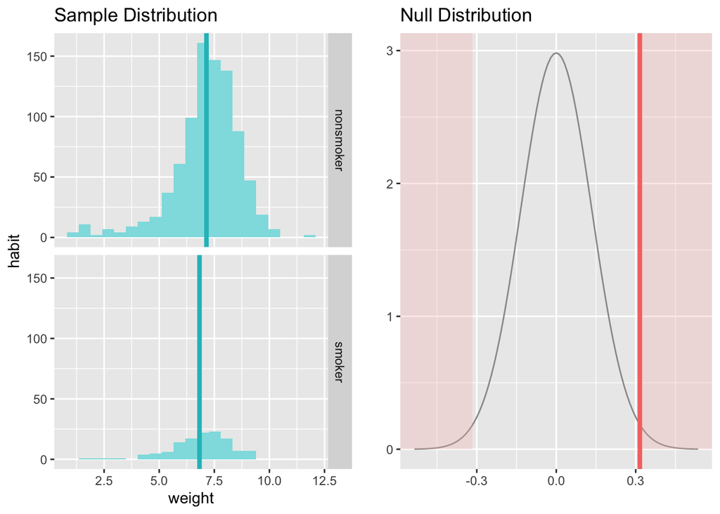

Let’s pause for a moment to go through the arguments of this function. The first argument is `y`, which is the response variable that we are interested in: `weight`. The second argument is the explanatory variable, `x`, which is the variable that splits the data into two groups, smokers and non-smokers: `habit`. The third argument, `data`, is the data frame these variables are stored in. Next is `statistic`, which is the sample statistic we’re using, or similarly, the population parameter we’re estimating. Recall in Lab 5 we worked with “proportion”. Next we decide on the `type` of inference we want: a hypothesis test (`"ht"`) or a confidence interval (`"ci"`). When performing a hypothesis test, we also need to supply the `null` value, which in this case is `0`, since the null hypothesis sets the two population means equal to each other. The `alternative` hypothesis can be `"less"`, `"greater"`, or `"twosided"`. Lastly, the `method` of inference can be `"theoretical"` or `"simulation"` based.

4. Interpret the output of the above function call (assume $\alpha=0.05$).

We see a p-value < 0.05, hence we reject the null hypothesis that the average weight in babies born to non-smokers and smokers is the same.

5. Now we change the `type` argument to `"ci"` to construct and record a confidence interval for the difference between the weights of babies born to nonsmoking and smoking mothers. Note that when doing a confidence interval arguments like `null` and `alternative` are not useful (these are only relevant for hypothesis tests), so we removed them.

```r
inference(y = weight, x = habit, data = nc, statistic = "mean", type = "ci",
          method = "theoretical")
```

```
## Response variable: numerical, Explanatory variable: categorical (2 levels)
## n_nonsmoker = 873, y_bar_nonsmoker = 7.1443, s_nonsmoker = 1.5187
## n_smoker = 126, y_bar_smoker = 6.8287, s_smoker = 1.3862
## 95% CI (nonsmoker - smoker): (0.0508 , 0.5803)
```

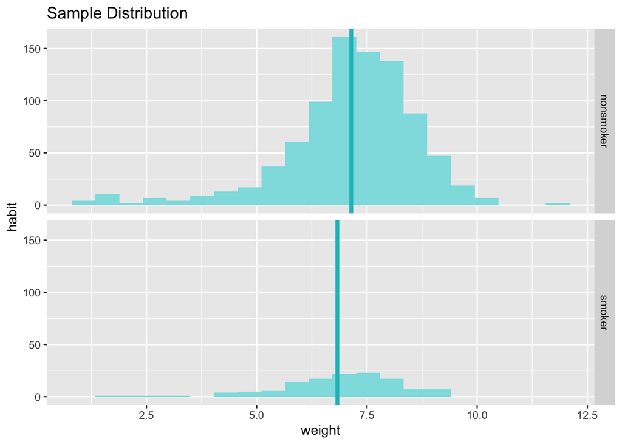

Interpret this interval in context of the data. Note that by default you’ll get a 95% confidence interval. If you want to change the confidence level, add a new argument (`conf_level`) which takes on a value between 0 and 1.

We see the 95% confidence interval for the weight difference in babies born to non-smokers and smokers is (.0508,.5803) with non-smokers having larger babies on average. We are 95% confident that the mean weight difference between babies born to smokers and non-smokers is between .0508 and .5803 pounds.

By default the function reports an interval for ($\mu_{nonsmoker} - \mu_{smoker}$). We can easily change this order by using the `order` argument:

```r
# Note the sign change on the CI (but same absolute values!)
inference(y = weight, x = habit, data = nc, statistic = "mean", type = "ci",
          method = "theoretical", order = c("smoker","nonsmoker"))
```

```
## Response variable: numerical, Explanatory variable: categorical (2 levels)
## n_smoker = 126, y_bar_smoker = 6.8287, s_smoker = 1.3862
## n_nonsmoker = 873, y_bar_nonsmoker = 7.1443, s_nonsmoker = 1.5187
## 95% CI (smoker - nonsmoker): (-0.5803 , -0.0508)
```

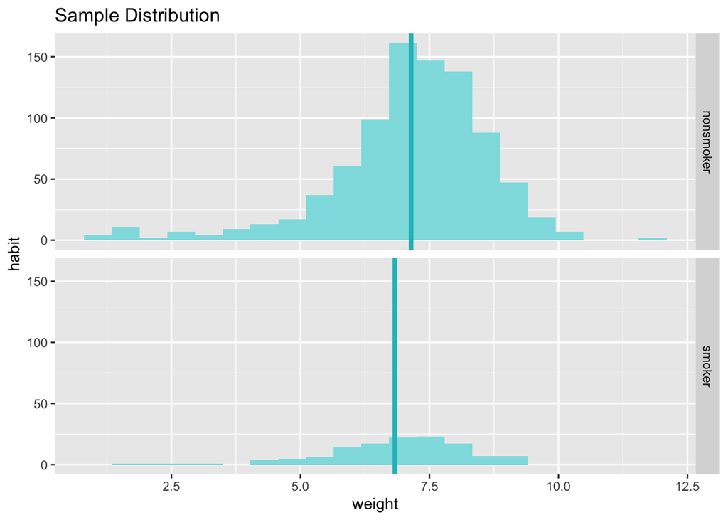

## On your own

6. Calculate a 95% confidence interval for the average length of pregnancies (`weeks`) using the `inference` function and interpret it in context. Note that since you’re doing inference on a single population parameter, there is no explanatory variable, so you can omit the `x` variable from the function.

```r
inference(y = weeks, data=nc, statistic = "mean", type = "ci", method = "theoretical")
```

```
## Single numerical variable
## n = 998, y-bar = 38.3347, s = 2.9316
## 95% CI: (38.1526 , 38.5168)
```

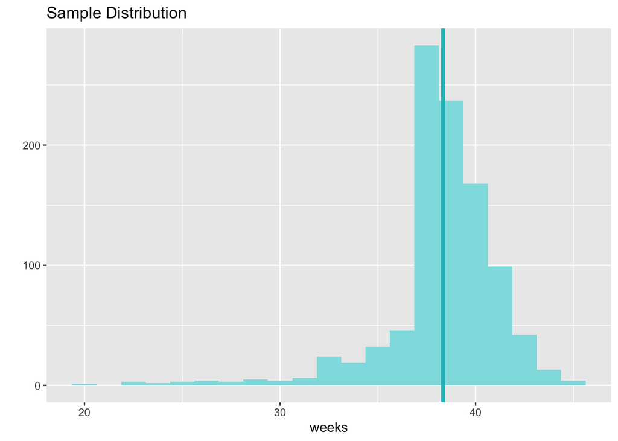

We are 95% confident that the true mean length of pregnacies lies between 38.1526 and 38.5168 weeks.

7. Calculate a new confidence interval for the same parameter at the 90% confidence level. You can change the confidence level by adding a new argument to the function: `conf_level = 0.90`. Comment on the width of this interval versus the one obtained in the the previous exercise.

```r
inference(y = weeks, data=nc, statistic = "mean", type = "ci", method = "theoretical", conf_level = 0.90)
```

```
## Single numerical variable
## n = 998, y-bar = 38.3347, s = 2.9316
## 90% CI: (38.1819 , 38.4874)
```

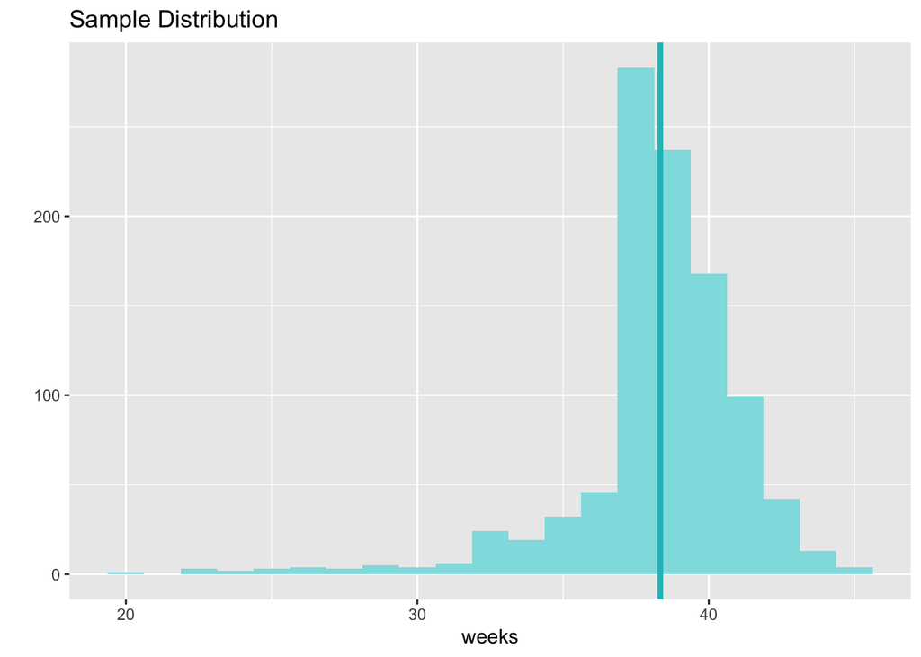

The width of this interval is narrower than  
the one obtained in the the previous exercise

8. Conduct a hypothesis test evaluating whether the average weight gained by younger mothers is different than the average weight gained by mature mothers. Use the standard $\alpha$ level.

Before running the test, we decide to use $\alpha = .05$.

```r
inference(y = gained, x = mature, data=nc, statistic = "mean", type = "ht", null = 0, alternative = "twosided", method = "theoretical")
```

```
## Response variable: numerical
## Explanatory variable: categorical (2 levels)
## n_mature mom = 129, y_bar_mature mom = 28.7907, s_mature mom = 13.4824
## n_younger mom = 844, y_bar_younger mom = 30.5604, s_younger mom = 14.3469
## H0: mu_mature mom =  mu_younger mom
## HA: mu_mature mom != mu_younger mom
## t = -1.3765, df = 128
## p_value = 0.1711
```

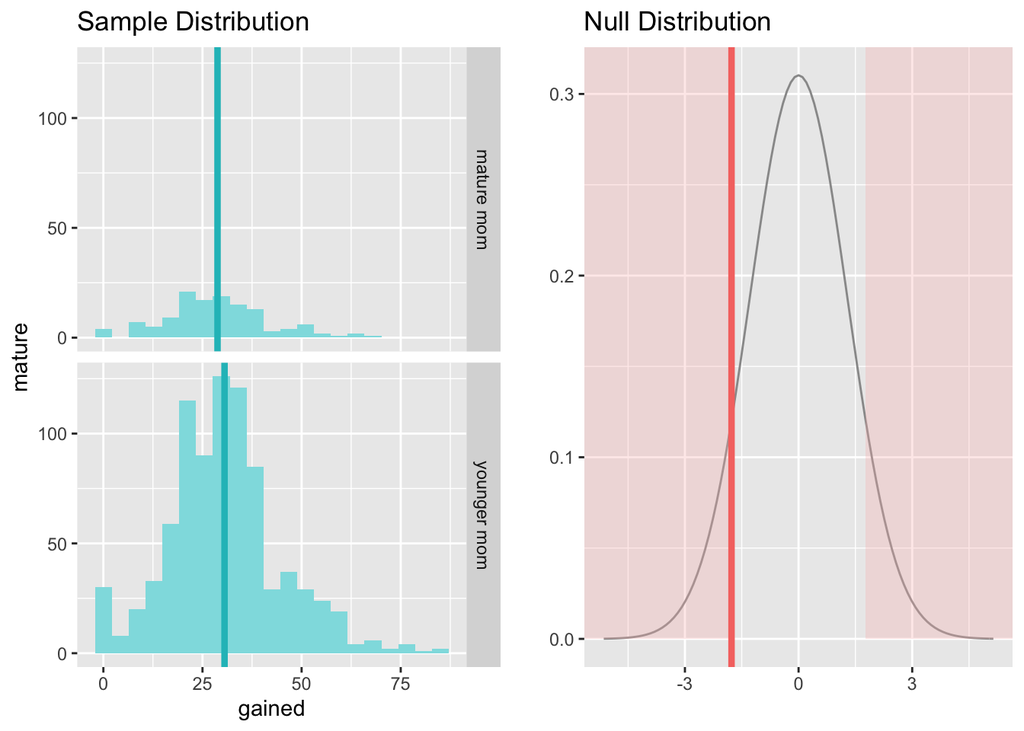

This is a product of OpenIntro that is released under a [Creative Commons Attribution-ShareAlike 3.0 Unported](http://creativecommons.org/licenses/by-sa/3.0). This lab was adapted for OpenIntro by Mine Çetinkaya-Rundel from a lab written by the faculty and TAs of UCLA Statistics.